# Chapter 01

date: 2017-08-03 moderator: Rene

This is out first R notebook to share and keep information about out sessions.

In R notebooks, you can include R code and see the output while being in the notebook, like this:

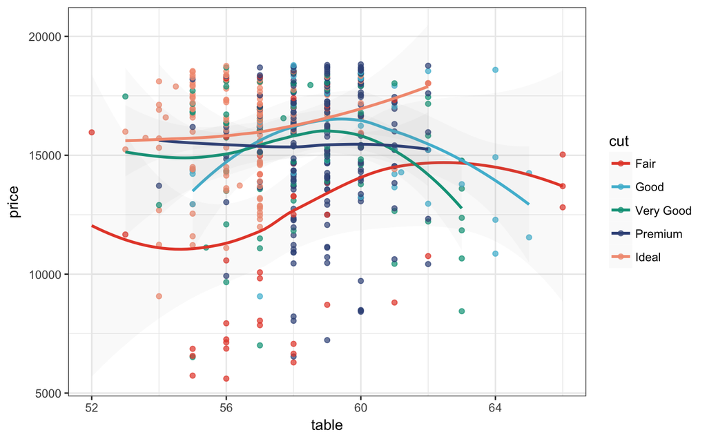

```r
library(tidyverse)
library(ggsci)
data("diamonds")
p1 = ggplot(subset(diamonds, carat >= 2.2),
            aes(x = table, y = price, colour = cut)) +
        geom_point(alpha = 0.7) +
        geom_smooth(method = "loess", alpha = 0.05, size = 1, span = 1) +
        theme_bw()
p1 + scale_color_npg()
```

Things we discussed today:

- The **general style** in which Richard writes is focussed on narratives that build up to the important points. This does not always work, like when he fails to explain the Saturn-image example. Hopefully, this style is more helpful than annoying in future chapters.
- As we go through this book, we want to draw conclusions about parallels between the Bayesian approach and **machine learning**, and answer for example: Does our type of data require Bayesian? What different assumptions do we me make in Bayesian compared to in machine learning?
- We agree that science is not only about reject Null-Hypothesis.
- We all look forward to learn about Information criterions, which we all already used.

Homework:

- Why does nature like the exponential family of functions? This has to do with Entropy, but why exactly does Entropy mean that many functions in nature look like a gaussian distribution?